# Marine Spatial Planning

Nelson Mandela African Institution of Science and Technology, Arusha, Tanzania

## Marine Planning

## Background—Ocean Uses

[figure not shown]

## Background—Ocean Uses

- Carefully planning is required to minimize conflicts and foster compatibilities among uses
- This planning process is termed *marine spatial planning (MSP)*,
- MSP foster sustainable ocean management and governance.

## Marine Spatial Planning

- MSP is a public process of `analyzing` and `allocating` the `spatial` and `temporal` distribution of *human activities* in **marine areas**
- The prime aspect of MSP are
  1. to achieve ecological, economic and social.
  2. to create and establish a more rational use of marine space and the interactions among its uses,
  3. to balance demands for development with the need to protect the environment, and
  4. to deliver social and economic outcomes in an open and planned way.

## Ocean Challenges

[figure not shown]

## Current Situation

## Current Situation

- Marine scientists face a challenge of synthesizing and communicating information from large and complex data sets.
- Growth in data and advance in computational, can make the process of communicating the results to decision makers in a meaningful way.
- The traditional approach of presenting information across a series of static slides and plots often fails to convey the richness of information available.

## Tanzania Sensitivity Atlas

- The institute of Marine Sciences developed the [Tanzania Sensitivity Atlas](https://ims.udsm.ac.tz/tansea/)
- IMS also involved in developing the [African Marine Atlas](http://www.africanmarineatlas.org/)

## GAP

## Existing

- Static
- Difficult to update

## Opportunity

## Tools for interactive visualization

- Interactive maps
- Interactive plots
- engage users and stakeholders
- easy to update the information
- backend serve as database

## Tools for Effective MSP

## Tools for MSP

- ocean management requires the integration and analysis of large and diverse data sets
- reproducible, and collaborative tools are needed to analyze, visualize, and update data in an efficient and cost-effective manner.
- Overcome the inherited challenge of traditional static outputs (e.g., tables, figures, reports, maps)+

## Interactive tools

- Interactive plots combined with spatial tools are effective way to communicate information used to inform decision-making processes such as
  - stock assessment,
  - ecosystem approaches to fisheries management,
  - conservation planning, and
  - marine spatial planning.

## Interactive Tools

- Interactive tools allows
  - The audience to interact with data and data products,
  - users to control over type of information
  - Users to download, filter, and re-plot the data to their desired test
  - Provide room to work in a more open and transparent manner.

## R languages for MSP

- R programming language has grown into a software that offers tools to build interactive tools for effective communication
- These web apps web applications are increasingly being used to explore research interactively.

## illutrative

## Static Terrain

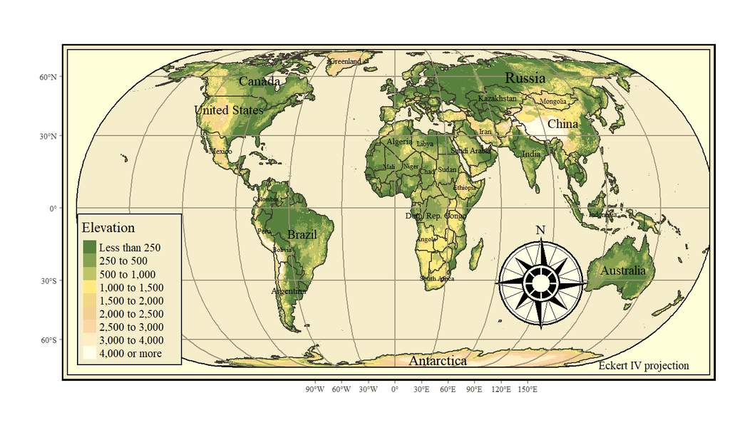

## Interactive Terrain

[interactive chart not shown]

## static pop

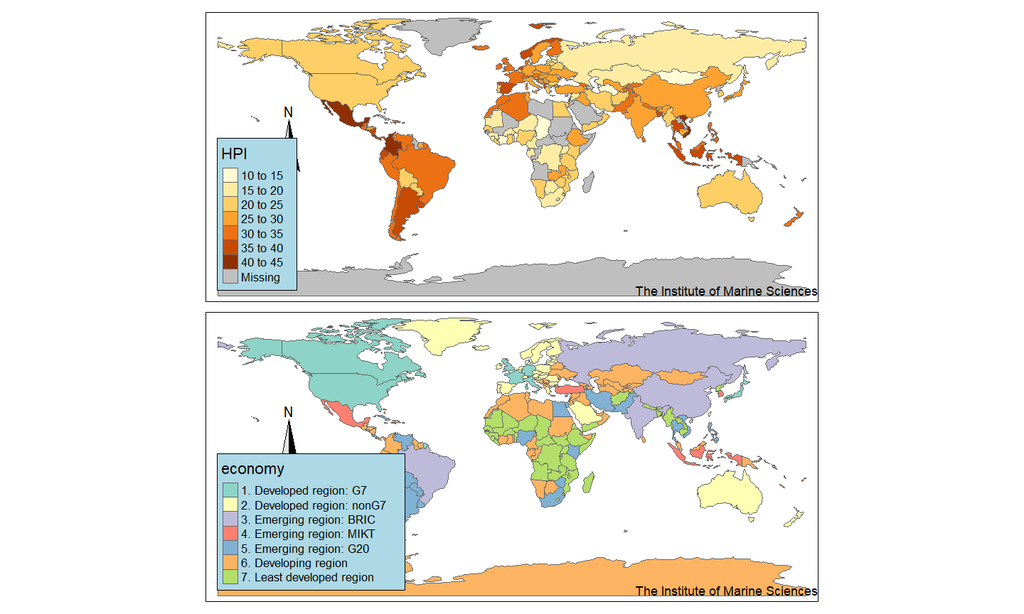

## Interactive pop

[interactive chart not shown]

## Conclusion

- The marine planning efforts should be flexible and adaptive to potential future alterations
- Regional and national policies should incorporate change to thrive in a dynamic and uncertain future.
- Regular update mechanisms must be established.